# Pobreza multidimensional comunal y puntaje Simce

Estadística Correlacional 2024, Carrera de Sociología - Universidad de Chile

Autores/as

Elisa Calderón

Sofía Rivera

Rocío Suárez

Amalia Tsukame

Felipe Vega

Fecha de publicación

29 de noviembre de 2024

Resumen

En base a la gran segregación socioeconómica existente en la Región Metropolitana, percibida en el indicador de pobreza multidimensional comunal, se sostiene la siguiente investigación, cuyo objetivo principal es conocer el nivel de asociación entre la pobreza multidimensional comunal y los puntajes Simce en establecimientos educacionales municipales de la Región Metropolitana durante el año 2022. De esta forma, se plantearon tres hipótesis principales, a las que se les aplicó la técnica de contraste de hipótesis nula. Para el análisis se emplearon datos proporcionados por el Ministerio de Desarrollo Social y Familia sobre las estimaciones de índice de pobreza multidimensional por comunas del año 2022, además, de ocupar los datos de la Agencia de Calidad de la Educación con relación al Simce del mismo año. Como resultado, las tres hipótesis nulas se rechazan con un nivel de confianza del 95%. En la primera, se emplea la correlación de Pearson, evidenciando una correlación grande, negativa y estadísticamente significativa, lo que quiere decir que existe una asociación significativa entre pobreza multidimensional comunal y puntaje Simce promedio a nivel comunal. En la segunda, se utiliza la prueba t, donde se evidencia a favor de la existencia estadísticamente significativa de que las comunas con niveles de pobreza bajo el promedio nacional obtienen puntajes más altos que el promedio de puntaje Simce de las columnas que se encuentran por sobre el promedio nacional. En la tercera hipótesis se emplea chi-cuadrado y V de Cramer, encontrando evidencia a favor de que existe una asociación nivel de pobreza multidimensional a nivel comunal y el nivel de puntajes insuficientes en el Simce.

# 1 Introducción

Dentro de la Región Metropolitana se puede percibir una gran segregación en términos socioeconómicos y de distribución de recursos. Esto provoca que, en algunos sectores de Santiago, existan bajos niveles educacionales, subempleo, y poco acceso a oportunidades (Rodríguez & Winchester, 2001).

En el ámbito educacional, según Rodríguez y Winchester (2001), las áreas periféricas poseen bajos recursos, afectando al deterioro continuo de la infraestructura, así que, las municipalidades deben dirigir sus recursos. Por otro lado, las escuelas privadas/subvencionadas, motivadas por su criterio comercial, buscan mantener prestigio, ofreciendo calidad educacional y mejores infraestructuras. Por tanto, la calidad del servicio varía según el tipo de sistema implementado, lo que es reafirmado por la prueba Simce, correspondiente a una medición estandarizada anual que permite conocer los resultados de los establecimientos educacionales en distintas asignaturas y sus respectivas habilidades (Agencia Calidad de la Educación, 2024). En esta, se especifica la brecha entre municipales y privados, pero que a la vez, muestra una rápida mejora de resultados en liceos municipales en los últimos años.

A partir de esto, la pobreza comunal es la proporción de personas pobres estimadas de cada comuna informada por el Ministerio sobre la base de la Encuesta Casen (Ministerio de Desarrollo Social y Familia, 2021). Dentro de los requerimientos para considerarse dentro de los estándares de pobreza, se emplea la pobreza multidimensional, definida por la Casen (2022), como la situación en la que un hogar enfrenta un 22,5% ó más de carencias en las dimensiones de educación, salud, trabajo y seguridad social, vivienda y entorno, y redes y cohesión social.

Este análisis es relevante ya que, como menciona el MINEDUC (s.f) los resultados de las pruebas Simce contribuyen con información clave que permite una reflexión sobre los aprendizajes logrados por los alumnos e identificar los desafíos que aportan a la reformulación de estrategias educativas, con el objetivo de mejorar los aprendizajes. Por esta razón, la investigación a desarrollar se consideraría un aporte al comparar los puntajes obtenidos por distintas comunas de la región, para lograr reforzar, nivelar y potenciar los aprendizajes en las comunas de mayor vulnerabilidad.

En base a aquello, el objetivo principal a trabajar es conocer el nivel de asociación entre la pobreza comunal y puntajes Simce en establecimientos educacionales municipales de la Región Metropolitana durante el año 2022. Se elaboraron distintas posibles hipótesis de los resultados esperados:

H1: Existe una alta asociación entre pobreza multidimensional comunal y puntaje Simce promedio a nivel comuna. Como hipótesis nula se plantea que no existe asociación entre pobreza multidimensional comunal y puntaje Simce promedio.

H2: El promedio de puntaje Simce de las comunas que se encuentran bajo el promedio nacional de pobreza es mayor que el promedio de puntaje Simce de las comunas que se encuentran por sobre el promedio nacional de pobreza. En este caso, la hipótesis corresponde a una diferencia direccional, planteándose como hipótesis nula que el promedio de puntaje Simce de las comunas bajo el promedio nacional es menor o igual que el promedio de puntaje Simce de las comunas que se encuentran sobre el promedio nacional de pobreza.

H3: Existe una alta asociación entre el nivel de puntajes deficientes en la prueba Simce y el nivel de pobreza multidimensional a nivel comunal. Como hipótesis nula se plantea que no existe asociación entre el nivel de pobreza multidimensional comunal y el nivel de puntajes deficientes en la prueba Simce.

# 2 Metodología

## 2.1 Datos

Se utilizaron los datos de las estimaciones de índice de pobreza multidimensional por comunas del año 2022 realizado por el Ministerio de Desarrollo Social y Familia (MIDESOF) y los datos del Simce del año 2022 entregados por la Agencia de Calidad de la Educación. En primera instancia, estas bases de datos fueron combinadas, luego, se trabajó con una submuestra, la que fue obtenida mediante tres filtros; establecimientos municipales, Región Metropolitana, y por comunas. Esto debido a que, según los objetivos planteados, se busca conocer la asociación entre la pobreza multidimensional comunal y los puntajes Simce de establecimientos municipales de la Región Metropolitana. Por lo tanto, la variable independiente es la pobreza multidimensional comunal y la variable dependiente son los puntajes de la prueba Simce. Además, a partir de la bibliografía anteriormente expuesta, la Región Metropolitana tiene la particularidad de que existe una alta segregación territorial que se puede ver expresada en la diferencia en el indicador de pobreza multidimensional de cada comuna. Por otra parte, es importante mencionar que, los establecimientos educacionales municipales dependen de cada comuna, por lo tanto, es pertinente estudiar el rendimiento comunal en este tipo de establecimientos.

Debido a que las variables a utilizar en este reporte se forman a partir del promedio de otras variables, no se tuvo que hacer un tratamiento de casos perdidos en particular. Sin embargo, se eliminaron seis comunas de la base de datos final (llamada “simce”) debido a que existían datos que no estaban presentes en las bases de datos originales, es decir, en las del Simce (Agencia de Calidad de la Educación, 2022) o MIDESOF (2022). Por lo tanto, en este reporte se trabajará con el 88,4% de las comunas de la Región Metropolitana, o sea, 46 de las 52 que se encuentran en este territorio.

## 2.2 Variables

**Pobreza multidimensional comunal**

La variable pob_multi mide la cantidad en porcentaje de hogares en situación de pobreza multidimensional en una comuna. Esta variable fue transformada de valores relativos a porcentajes, de manera que, sus valores teóricos van de 0 a 100 expresado en puntos porcentuales.

La Figura 1 muestra un resumen de los estadísticos descriptivos de la variable pobreza multidimensional comunal.

Pobreza multidimensional comunal en RM

| Tamaño muestral | Mínimo | Máximo | Media | Desv. estándar | Cuartil 1 | Mediana (Cuartil 2) | Cuartil 3 |
| --- | --- | --- | --- | --- | --- | --- | --- |
| 46 | 2.442412 | 31.92779 | 18.88 | 6.92 | 16.51 | 19.29549 | 22.86042 |

<sup>a</sup> Fuente: Elaboración propia en base a MIDESOF 2022.

Figura 1: Pobreza multidimensional comunal en RM

**Nivel de pobreza multidimensional comunal con respecto al promedio nacional**

Luego, la variable anterior fue recodificada de una tipo numérica a una dicotómica, llamada pob_multi_dic. En este sentido, esta variable presenta valores de 0 y 1, donde 0 significa “Pobreza comunal bajo el promedio nacional”, y 1, “Pobreza comunal sobre el promedio nacional”. Esta recodificación se realizó a partir de la cantidad porcentual promedio de pobreza multidimensional comunal a nivel nacional, la cual es de 19% en el año 2022.

La Figura 2 muestra la frecuencia relativa y porcentual de la variable anteriormente mencionada.

Nivel de pobreza multidimensional comunal con respecto al promedio nacional

| Pobreza multidimensional Comunal | Frecuencia | Frecuencia porcentual |
| --- | --- | --- |
| Pobreza comunal bajo promedio nacional | 21 | 45.65 |
| Pobreza comunal sobre promedio nacional | 25 | 54.35 |

<sup>a</sup> Fuente: Elaboración propia en base a MIDESOF 2022.

Figura 2: Nivel de pobreza multidimensional comunal con respecto al promedio nacional

**Puntaje Simce promedio comunal**

La variable prom_simce corresponde al nivel promedio de puntaje Simce de las comunas de la Región Metropolitana. Esta variable se calculó a partir del promedio entre los puntajes de lectura y de matemática obtenidos en cada establecimiento. Luego, ese valor fue promediado para así obtener la media de los establecimientos municipales de cada comuna de la región. A pesar de que no existe un mínimo y máximo de puntaje que se puede obtener en el Simce debido a que esta escala puede cambiar de año a año, a nivel nacional, los puntajes varían aproximadamente de 155 a 409 puntos en la base de datos del año 2022.

La Figura 3 muestra un resumen de los estadísticos descriptivos de la variable promedio Simce comunal.

Puntaje Simce promedio comunal en la Región Metropolitana

| Tamaño muestral | Mínimo | Máximo | Media | Desv. estándar | Cuartil 1 | Mediana (Cuartil 2) | Cuartil 3 |
| --- | --- | --- | --- | --- | --- | --- | --- |
| 46 | 205.25 | 304.1667 | 229.4 | 18.72 | 218.7708 | 225.225 | 231.5 |

<sup>a</sup> Fuente: Elaboración propia en base a la Agencia de Calidad de la Educación 2022.

Figura 3: Puntaje Simce promedio comunal en la Región Metropolitana

**Nivel de puntaje Simce promedio comunal con respecto al promedio nacional**

Luego, la variable anterior fue recodificada de una tipo numérica a una dicotómica, llamada prom_simce_dic. En este sentido, los valores de esta variable presentan valores de 0 y 1, donde 0 significa “Puntaje Simce bajo promedio nacional”, y 1, “Puntaje Simce promedio nacional”. Esta recodificación se realizó a partir del puntaje Simce promedio a nivel nacional, el cual es de 248.84 en el año 2022.

La Figura 4 muestra la frecuencia relativa y porcentual de la variable anteriormente mencionada.

Nivel de puntaje Simce promedio comunal

| Nivel de puntaje Simce promedio comunal | Frecuencia | Frecuencia porcentual |
| --- | --- | --- |
| Puntaje Simce bajo promedio nacional | 40 | 86.96 |
| Puntaje Simce sobre promedio nacional | 6 | 13.04 |

<sup>a</sup> Fuente: Elaboración propia en base a la Agencia de Calidad de la Educación 2022.

Figura 4: Nivel de puntaje Simce promedio comunal

**Cantidad porcentual promedio de alumnos con puntajes insuficientes Simce**

La variable sobre cantidad porcentual de alumnos promedio que obtuvieron puntajes Simce insuficientes se calculó a partir del promedio entre la cantidad de alumnos con puntajes de lectura y matemática insuficientes. De esta forma, la variable va de valores de 0 a 100, expresada en porcentaje. A continuación, la Figura 5 muestra un resumen de los estadísticos descriptivos de la variable.

Tabla 5. Porcentaje promedio de alumnos con puntajes Simce insuficientes a nivel comunal

| Tamaño muestral | Mínimo | Máximo | Media | Desv. estándar | Cuartil 1 | Mediana (Cuartil 2) | Cuartil 3 |
| --- | --- | --- | --- | --- | --- | --- | --- |
| 46 | 17.175 | 85.55 | 67.25 | 13.53 | 62.77917 | 69.59545 | 74.8875 |

<sup>a</sup> Fuente: Elaboración propia en base a la Agencia de Calidad de la Educación 2022.

Figura 5: Porcentaje promedio de alumnos con puntajes Simce insuficientes a nivel comunal

**Nivel promedio de alumnos con puntajes insuficientes Simce**

La variable anterior fue recodificada de una variable numérica a una ordinal de manera proporcional, la cual se le llamó nivel_insuficiencia_or. En función de esto, sus valores son 0 cuando el porcentaje es mayor o igual a 0 hasta un 33%, siendo nombrada como “Bajo”; 1 cuando el valor se encuentra entre 33% y 67%, se nombró como “Medio”; por último 2 cuando este es mayor a 67% hasta el 100%, siendo nombrada como “Alta”. Cabe recalcar que esta recodificación se realizó a partir de un criterio de proporcionalidad, es decir, que cada rango contemplara aproximadamente un 33% del total (100%). La Figura 6 muestra las frecuencias de cada nivel.

Nivel promedio de alumnos con puntajes insuficientes Simce a nivel comunal

| Nivel promedio de puntajes insuficientes | Frecuencia | Frecuencia porcentual |
| --- | --- | --- |
| Bajo | 1 | 2.17 |
| Medio | 17 | 36.96 |
| Alto | 28 | 60.87 |

<sup>a</sup> Fuente: Elaboración propia en base a la Agencia de Calidad de la Educación 2022.

Figura 6: Nivel promedio de alumnos con puntajes insuficientes Simce a nivel comunal

## 2.3 Métodos

Para contrastar las hipótesis planteadas, se utilizará la técnica de contraste de hipótesis nula para conocer si hay evidencia a su favor que permita extrapolar los datos a la población. En primer lugar, para la primera hipótesis se utilizará el coeficiente de correlación de Pearson para conocer la asociación entre las variables puntaje Simce y la pobreza multidimensional comunal. En segundo lugar, para la segunda hipótesis se utilizará la prueba t Student ya que se trabaja con la diferencia de medias. Por último, se ocupará el método chi-cuadrado para la última hipótesis debido a que las variables son categóricas, específicamente nominal y ordinal.

# 3 Análisis

## 3.1 Análisis descriptivo

Para las variables presentadas, se calcularon diferentes estadísticos descriptivos para realizar el análisis.

En relación a lo anterior, la Figura 1 muestra que la variable de la pobreza multidimensional comunal en la Región Metropolitana varía en un rango de 2,4% y 31,9%, se puede observar que la media es de 18,8% con una desviación estándar de 6,92%. Además, la mediana se encuentra un poco más alta que el promedio con un valor de 19,3%. Por otro lado, se tiene que, un 75% de la muestra se encuentra por debajo de un 22,8% de pobreza multidimensional.

Para la variable de nivel de pobreza multidimensional comunal con respecto al promedio nacional (Figura 2) se tiene que 21 comunas de la Región Metropolitana, que equivale al 45,7% de la muestra, se encuentran bajo el promedio de pobreza comunal. En cambio, un 54,3% se encuentra sobre el promedio.

El puntaje Simce promedio comunal en la Región Metropolitana indicados en la Figura 3 indican que el puntaje promedio del Simce es de 229 puntos con una desviación estándar de 18,72 puntos. Esta variable va en un rango de un mínimo de 205 y como valor máximo de 304 expresado en puntaje. En relación al tercer cuartil, se tiene que un 75% de la muestra se encuentra por debajo de los 231 puntos.

Luego, para la variable nivel de puntaje Simce promedio comunal (Figura 4) se tiene que un 87% de la muestra tiene un puntaje Simce bajo el promedio. De manera que solo 6 datos correspondiente al 13% son puntajes Simce sobre el promedio.

Con respecto al porcentaje promedio de alumnos con puntaje Simce insuficientes a nivel comunal, la Figura 5 señala que los valores de esta variable va en un rango de 17,18% a 85,55%, el porcentaje promedio es de 67,25%, con una desviación estándar de 13,53. La mediana es un poco más alta que la media donde el 50% de las comunas tiene un valor de 69,6% o menos de estudiantes con puntaje Simce insuficientes, por otro lado, el 75% de la muestra tiene un 74% de los alumnos con un promedio del puntaje simce insuficiente.

En la variable del nivel promedio de alumnos con puntajes insuficientes Simce, la Figura 6 da cuenta de que la mayoría de las comunas tiene un nivel alto de puntajes Simce insuficientes, siendo esta de 60,87% de la Región Metropolitana. Por otro lado, el segundo caso más alto es el medio donde el 36,96% de las comunas se encuentra en este nivel, representando a 17 comunas de la región. Por último, solo existe una comuna con niveles bajo de insuficiencia en los puntajes promedio Simce comunales, esta representa el 2,17%.

## 3.2 Análisis estadístico bivariado

**Hipótesis 1: Correlación de Pearson entre Promedio Simce comunal y Pobreza multidimensional comunal**

Para realizar el análisis bivariado de la primera hipótesis se utilizó el coeficiente de Pearson. El valor obtenido fue de -0,72 lo que indica una correlación grande y negativa. El valor de p es 0,001 siendo menor al valor teórico (p<0.05) de manera que la correlación es estadísticamente significativa (Figura 7). De esta manera, con un 95% de confianza, es posible rechazar la hipótesis nula de que no existe asociación entre pobreza multidimensional comunal y puntaje Simce promedio y, por lo tanto, se puede afirmar que existe una asociación estadísticamente significativa entre las variables pobreza multidimensional comunal y el puntaje Simce promedio a nivel comunal.

| Estimación | t | p-value | df | Método | Alternativa | 95% IC |
| --- | --- | --- | --- | --- | --- | --- |
| -0.72 | -6.89 | < 0.001*** | 44 | Pearson’s product-moment correlation | two.sided | [-0.84,-0.54] |

Figura 7: Correlación de Pearson entre Promedio Simce comunal y Pobreza multidimensional comunal

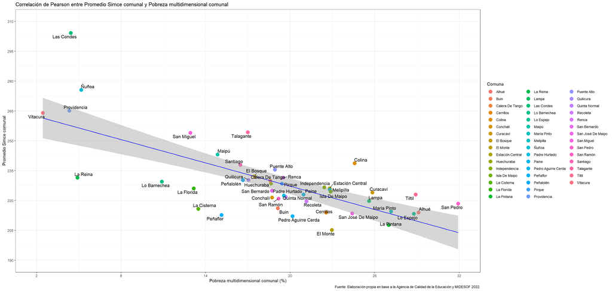

Figura 8: Correlación de Pearson entre Promedio Simce comunal y Pobreza multidimensional comunal

**Hipótesis 2: Diferencia de medias entre Promedio Simce comunal y nivel de Pobreza multidimensional comunal con respecto al promedio nacional**

En segundo lugar, se realizó la prueba t para la segunda hipótesis alternativa, la cual corresponde a que el promedio de puntaje Simce de las comunas que se encuentran bajo el promedio nacional es mayor que el promedio de puntaje Simce de las comunas que se encuentran por sobre el promedio nacional de pobreza. Por el contrario, la hipótesis nula es que el promedio de puntaje Simce de las comunas bajo el promedio nacional es menor o igual que el promedio de puntaje Simce de las comunas que se encuentran sobre el promedio nacional de pobreza.

| Method | Alternative | Mean 1 | Mean 2 | M1 - M2 | t | df | p | 95% CI |
| --- | --- | --- | --- | --- | --- | --- | --- | --- |
| Welch Two Sample t-test | greater | 240.34 | 220.21 | 20.13 | 3.98 | 23.92 | < .001*** | [11.48, Inf] |

Figura 9: Diferencia de medias entre Promedio Simce comunal y nivel de Pobreza multidimensional comunal con respecto al promedio nacional

En este sentido, a partir del Figura 10 se puede observar que las comunas bajo el promedio nacional pobreza multidimensional tienen un puntaje Simce promedio de 240,34 puntos. Mientras que, las comunas sobre el promedio de pobreza, obtienen un puntaje promedio de 220,21 puntos. De esta forma, se puede establecer que existe una diferencia significativa de 20,13 puntos promedio en la muestra entre las comunas que se encuentran bajo y sobre el promedio nacional.

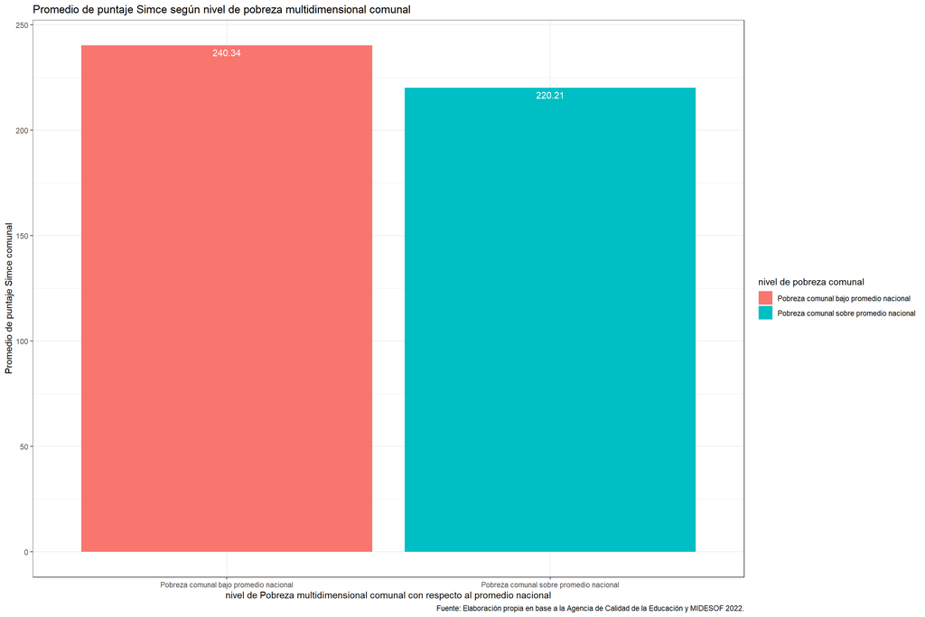

Figura 10: Diferencia de medias entre Promedio Simce comunal y nivel de Pobreza multidimensional comunal con respecto al promedio nacional

**Hipótesis 3: Chi-cuadrado entre nivel de Pobreza multidimensional comunal con respecto al promedio nacional y Nivel promedio de alumnos con puntajes insuficientes Simce**

Por último, para la tercera hipótesis y como se observa en la tabla de contingencia (Figura 11), en comunas con pobreza bajo el promedio nacional, un 61.9% de la muestra presenta niveles medios de puntajes insuficientes, mientras que, en comunas con pobreza sobre el promedio nacional, predominan los niveles altos de puntajes insuficientes con un 84%.

Por otro lado, al realizar la prueba chi-cuadrado el valor empírico dio como resultado 12.511 (p = 0,002), lo que es mayor que el chi-cuadrado crítico que fue de 5.991. También, el valor de V de Cramer es de 0.522, que indica que la magnitud de la asociación entre las variables es moderada-fuerte según los criterios de Cohen. Esta comparación quiere decir que se rechaza la hipótesis nula, por tanto se puede concluir que existe evidencia a favor de la hipótesis alternativa de asociación entre variables. Por ende, se puede afirmar, con un 95% de confianza, que en la población existe una asociación entre el nivel de puntajes insuficientes en la prueba Simce y el nivel de pobreza multidimensional a nivel comunal.

| Nivel de pobreza multidimensional comunal | Nivel de alumnos con puntajes Simce insuficientes |  |  | Total |  |
| --- | --- | --- | --- | --- | --- |
|  | Bajo | Medio | Alto |  |  |
| Pobreza comunal bajo promedio nacional | 1 4.8 % 100 % | 13 61.9 % 76.5 % | 7 33.3 % 25 % |  | 21 100 % 45.7 % |
| Pobreza comunal sobre promedio nacional | 0 0 % 0 % | 4 16 % 23.5 % | 21 84 % 75 % | 25 100 % 54.3 % |  |
| Total | 1 2.2 % 100 % | 17 37 % 100 % | 28 60.9 % 100 % | 46 100 % 100 % |  |
| χ<sup>2</sup>=12.511 · df=2 · Cramer’s V=0.522 · Fisher’s p=0.002 |  |  |  |  |  |

Figura 11: Tabla de contingencia entre nivel de Pobreza multidimensional comunal con respecto al promedio nacional y Nivel promedio de alumnos con puntajes insuficientes Simce

# 4 Conclusiones

En resumen, las tres hipótesis planteadas se validan, siendo estadísticamente significativas con un nivel de confianza del 95%. En este sentido, en primer lugar, existe evidencia a favor de que hay una alta asociación entre la pobreza multidimensional comunal y el puntaje promedio Simce de las comunas. En segundo lugar, el puntaje promedio Simce en las comunas con pobreza multidimensional inferior al promedio nacional supera al de las comunas con pobreza superior al promedio nacional. Finalmente, se confirma una asociación entre el nivel de estudiantes con puntajes Simce insuficientes y el grado de pobreza multidimensional a nivel comunal, según los resultados obtenidos de la prueba de chi-cuadrado.

En relación con las limitaciones, se tiene, en primer lugar, que establecimientos de algunas comunas no fueron considerados ya que sus puntajes Simce no están registrados en la base de datos. Por otro lado, realizar un análisis de los puntajes Simce es complejo debido que no tiene puntajes mínimos ni máximos, por lo tanto, no existe un parámetro delimitador que defina y estratifique entre puntajes, lo cuál dificulta el proceso de cuantificar los datos y medirlos. Además, los puntajes son recodificados a partir de múltiples factores socioeconómicos de los establecimientos que influyen en la calidad de la educación, como por ejemplo la calidad de los docentes, de la infraestructura o el contexto familiar, y no en función de los puntajes por sí mismos. Por último, la mayoría de las variables utilizadas fueron los promedios entre las medias de cada establecimiento para las pruebas Simce de lectura y matemática, por lo tanto, se debe tener en cuenta que los resultados obtenidos son en su totalidad promedios, y estos pueden tener la limitación de no considerar la dispersión de los datos en la muestra. Cabe mencionar que, a pesar de lo anteriormente mencionado, posiblemente los tamaños de magnitud entre las asociaciones entre variables dieron resultados grandes debido a la cantidad pequeña de observaciones que se utilizaron (46 comunas), factor que se debería tener en consideración para futuras investigaciones donde se analicen comunas.

Como sugerencia para futuras investigaciones, se podría considerar, en primer lugar, realizar análisis diferenciados entre las pruebas de lectura y de matemática o, en segundo lugar, ampliar la población estudiada a otras regiones y analizar cómo se distribuyen los puntajes Simce en los sectores norte y sur del país; esto permitirá que cada municipio del país se pueda desarrollar a la par con la Región Metropolitana. Es importante que los municipios tengan en consideración la asociación entre la pobreza comunal y los puntajes Simce, lo cual argumenta una redistribución de recursos con un especial enfoque en el desarrollo comunal y un mejor financiamiento para la educación.

# 5 Bibliografía

Agencia de Calidad de la Educación. (2022). Tabla con puntajes promedio a nivel de establecimientos del proceso SIMCE 2022. https://informacionestadistica.agenciaeducacion.cl/#/bases

Agencia de Calidad de la Educación. (s.f.). SIMCE: Sistema de Medición de la Calidad de la Educación. Recuperado el 21, noviembre, 2024, de https://www.agenciaeducacion.cl/simce/

Casen. (2022). Resultados pobreza multidimensional Casen 2022 (versión 20 octubre 2023). Observatorio Social. https://observatorio.ministeriodesarrollosocial.gob.cl/storage/docs/casen/2022/Resultados_Pobreza_Multidimensional_Casen_2022_v20oct23.pdf

Ministerio de Desarrollo Social y Familia. (2020). Informe SAE 2020: Pobreza comunal en Chile. Observatorio Social. https://observatorio.ministeriodesarrollosocial.gob.cl/storage/docs/pobreza-comunal/2020/Informe_SAE_2020.pdf

Ministerio de Desarrollo Social y Familia. (2022). Estimaciones del Índice de Pobreza Multidimensional (H) por Comuna 2022. Observatorio Social. https://observatorio.ministeriodesarrollosocial.gob.cl/pobreza-comunal-2022

Ministerio de Desarrollo Social y Familia. (s.f.). Preguntas frecuentes. Observatorio Social. Recuperado el 21 de noviembre de 2024, de https://observatorio.ministeriodesarrollosocial.gob.cl/preguntas-frecuentes

Ministerio de Desarrollo Social y Familia. (2022). Pobreza comunal 2022. Observatorio Social. https://observatorio.ministeriodesarrollosocial.gob.cl/pobreza-comunal-2022

Ministerio de Educación. (s.f.). SIMCE. Ayuda Mineduc. Recuperado el 21 de noviembre de 2024, de https://www.ayudamineduc.cl/ficha/simce

Rodríguez, A, & Winchester, L. (2001). Santiago de Chile: Metropolización, globalización, desigualdad. EURE (Santiago), 27(80), 121-139. https://dx.doi.org/10.4067/S0250-71612001008000006